# WEEKLY_ASSIGNMENT_3_BALMES_I

## WEEKLY_ASSIGNMENT_3_BALMES_I

4.1 Breakfast Cereals. Use the data for the breakfast cereals example to explore and summarize the data as follows:

a. Which variables are quantitative/numerical? Which are ordinal? Which are nominal?

*The quantitative variables are: Calories, Protein, Fat, Sodium, Fiber, Carbo, Sugars, Potass, Vitamins, Shelf, Weight, and Cups. Rating is an ordinal variable while nominal variables include Mfr, Type and Shelf.*

b. Compute the mean, median, min, max, and standard deviation for each of the quantitative variables.

```python
import numpy as np
import pandas as pd
from sklearn.decomposition import PCA
from sklearn import preprocessing
import matplotlib.pylab as plt
```

```python
cereals_df = pd.read_csv('Cereals.csv')
cereals_df = cereals_df.rename(columns={'CAT. MEDV': 'CAT_MEDV'})
cereals_df.head(9)
cereals_df.describe()
```

|  | calories | protein | fat | sodium | fiber | carbo | sugars | potass | vitamins | shelf | weight | cups | rating |
| --- | --- | --- | --- | --- | --- | --- | --- | --- | --- | --- | --- | --- | --- |
| count | 77.000000 | 77.000000 | 77.000000 | 77.000000 | 77.000000 | 76.000000 | 76.000000 | 75.000000 | 77.000000 | 77.000000 | 77.000000 | 77.000000 | 77.000000 |
| mean | 106.883117 | 2.545455 | 1.012987 | 159.675325 | 2.151948 | 14.802632 | 7.026316 | 98.666667 | 28.246753 | 2.207792 | 1.029610 | 0.821039 | 42.665705 |
| std | 19.484119 | 1.094790 | 1.006473 | 83.832295 | 2.383364 | 3.907326 | 4.378656 | 70.410636 | 22.342523 | 0.832524 | 0.150477 | 0.232716 | 14.047289 |
| min | 50.000000 | 1.000000 | 0.000000 | 0.000000 | 0.000000 | 5.000000 | 0.000000 | 15.000000 | 0.000000 | 1.000000 | 0.500000 | 0.250000 | 18.042851 |
| 25% | 100.000000 | 2.000000 | 0.000000 | 130.000000 | 1.000000 | 12.000000 | 3.000000 | 42.500000 | 25.000000 | 1.000000 | 1.000000 | 0.670000 | 33.174094 |
| 50% | 110.000000 | 3.000000 | 1.000000 | 180.000000 | 2.000000 | 14.500000 | 7.000000 | 90.000000 | 25.000000 | 2.000000 | 1.000000 | 0.750000 | 40.400208 |
| 75% | 110.000000 | 3.000000 | 2.000000 | 210.000000 | 3.000000 | 17.000000 | 11.000000 | 120.000000 | 25.000000 | 3.000000 | 1.000000 | 1.000000 | 50.828392 |
| max | 160.000000 | 6.000000 | 5.000000 | 320.000000 | 14.000000 | 23.000000 | 15.000000 | 330.000000 | 100.000000 | 3.000000 | 1.500000 | 1.500000 | 93.704912 |

```python
pd.DataFrame({'mean': cereals_df.mean(),
'median': cereals_df.median(),
'min': cereals_df.min(),
'max': cereals_df.max(),
'sd': cereals_df.std(),
})
```

|  | mean | median | min | max | sd |
| --- | --- | --- | --- | --- | --- |
| calories | 106.883117 | 110.000000 | 50 | 160 | 19.484119 |
| carbo | 14.802632 | 14.500000 | 5 | 23 | 3.907326 |
| cups | 0.821039 | 0.750000 | 0.25 | 1.5 | 0.232716 |
| fat | 1.012987 | 1.000000 | 0 | 5 | 1.006473 |
| fiber | 2.151948 | 2.000000 | 0 | 14 | 2.383364 |
| mfr | NaN | NaN | A | R | NaN |
| name | NaN | NaN | 100%_Bran | Wheaties_Honey_Gold | NaN |
| potass | 98.666667 | 90.000000 | 15 | 330 | 70.410636 |
| protein | 2.545455 | 3.000000 | 1 | 6 | 1.094790 |
| rating | 42.665705 | 40.400208 | 18.0429 | 93.7049 | 14.047289 |
| shelf | 2.207792 | 2.000000 | 1 | 3 | 0.832524 |
| sodium | 159.675325 | 180.000000 | 0 | 320 | 83.832295 |
| sugars | 7.026316 | 7.000000 | 0 | 15 | 4.378656 |
| type | NaN | NaN | C | H | NaN |
| vitamins | 28.246753 | 25.000000 | 0 | 100 | 22.342523 |
| weight | 1.029610 | 1.000000 | 0.5 | 1.5 | 0.150477 |

c. Plot a histogram for each of the quantitative variables. Based on the histograms and summary statistics, answer the following questions:

i. Which variables have the largest variability? ii. Which variables seem skewed?

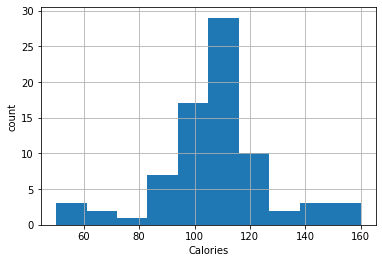

```python
ax = cereals_df.calories.hist()
ax.set_xlabel('Calories'); ax.set_ylabel('count')
```

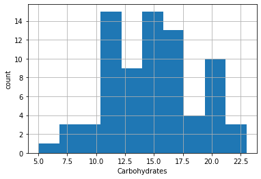

```python
ax = cereals_df.carbo.hist()
ax.set_xlabel('Carbohydrates'); ax.set_ylabel('count')
```

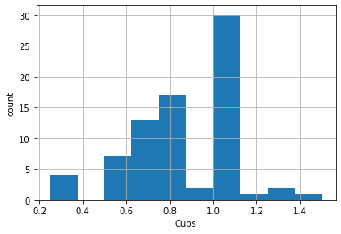

```python
ax = cereals_df.cups.hist()
ax.set_xlabel('Cups'); ax.set_ylabel('count')
```

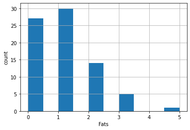

```python
ax = cereals_df.fat.hist()
ax.set_xlabel('Fats'); ax.set_ylabel('count')
```

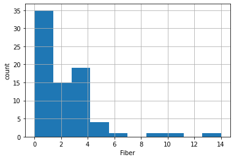

```python
ax = cereals_df.fiber.hist()
ax.set_xlabel('Fiber'); ax.set_ylabel('count')
```

[figure not shown]

```python
ax = cereals_df.potass.hist()
ax.set_xlabel('Protein'); ax.set_ylabel('count')
```

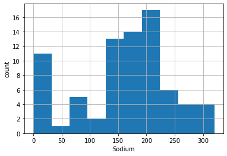

```python
ax = cereals_df.sodium.hist()
ax.set_xlabel('Sodium'); ax.set_ylabel('count')
```

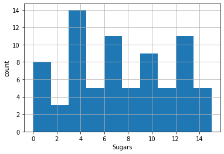

```python
ax = cereals_df.sugars.hist()
ax.set_xlabel('Sugars'); ax.set_ylabel('count')
```

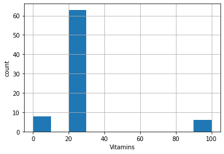

```python
ax = cereals_df.vitamins.hist()
ax.set_xlabel('Vitamins'); ax.set_ylabel('count')
```

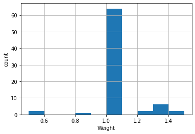

```python
ax = cereals_df.weight.hist()
ax.set_xlabel('Weight'); ax.set_ylabel('count')
```

i. Which pair of variables is most strongly correlated?

```python
cereals_df.corr().round(2)
```

|  | calories | protein | fat | sodium | fiber | carbo | sugars | potass | vitamins | shelf | weight | cups | rating |
| --- | --- | --- | --- | --- | --- | --- | --- | --- | --- | --- | --- | --- | --- |
| calories | 1.00 | 0.02 | 0.50 | 0.30 | -0.29 | 0.26 | 0.57 | -0.07 | 0.27 | 0.10 | 0.70 | 0.09 | -0.69 |
| protein | 0.02 | 1.00 | 0.21 | -0.05 | 0.50 | -0.03 | -0.29 | 0.56 | 0.01 | 0.13 | 0.22 | -0.24 | 0.47 |
| fat | 0.50 | 0.21 | 1.00 | -0.01 | 0.02 | -0.30 | 0.30 | 0.20 | -0.03 | 0.26 | 0.21 | -0.18 | -0.41 |
| sodium | 0.30 | -0.05 | -0.01 | 1.00 | -0.07 | 0.30 | 0.06 | -0.04 | 0.36 | -0.07 | 0.31 | 0.12 | -0.40 |
| fiber | -0.29 | 0.50 | 0.02 | -0.07 | 1.00 | -0.38 | -0.14 | 0.91 | -0.03 | 0.30 | 0.25 | -0.51 | 0.58 |
| carbo | 0.26 | -0.03 | -0.30 | 0.30 | -0.38 | 1.00 | -0.47 | -0.37 | 0.22 | -0.19 | 0.14 | 0.37 | 0.09 |
| sugars | 0.57 | -0.29 | 0.30 | 0.06 | -0.14 | -0.47 | 1.00 | 0.00 | 0.10 | 0.07 | 0.46 | -0.05 | -0.76 |
| potass | -0.07 | 0.56 | 0.20 | -0.04 | 0.91 | -0.37 | 0.00 | 1.00 | -0.01 | 0.39 | 0.42 | -0.50 | 0.42 |
| vitamins | 0.27 | 0.01 | -0.03 | 0.36 | -0.03 | 0.22 | 0.10 | -0.01 | 1.00 | 0.30 | 0.32 | 0.13 | -0.24 |
| shelf | 0.10 | 0.13 | 0.26 | -0.07 | 0.30 | -0.19 | 0.07 | 0.39 | 0.30 | 1.00 | 0.19 | -0.34 | 0.03 |
| weight | 0.70 | 0.22 | 0.21 | 0.31 | 0.25 | 0.14 | 0.46 | 0.42 | 0.32 | 0.19 | 1.00 | -0.20 | -0.30 |
| cups | 0.09 | -0.24 | -0.18 | 0.12 | -0.51 | 0.37 | -0.05 | -0.50 | 0.13 | -0.34 | -0.20 | 1.00 | -0.20 |
| rating | -0.69 | 0.47 | -0.41 | -0.40 | 0.58 | 0.09 | -0.76 | 0.42 | -0.24 | 0.03 | -0.30 | -0.20 | 1.00 |

1. University Rankings. The dataset on American college and university rankings contains information on 1302 American colleges and universities offering an undergraduate program. For each university, there are 17 measurements that include continuous measurements (such as tuition and graduation rate) and categorical measurements (such as location by state and whether it is a private or a public school).

a. Remove all categorical variables. Then remove all records with missing numerical measurements from the dataset.

```python
universities_df = pd.read_csv('Universities.csv')
```

```python
universities_df.dropna(how='any')
```

|  | College Name | State | Public (1)/ Private (2) | # appli. rec'd | # appl. accepted | # new stud. enrolled | % new stud. from top 10% | % new stud. from top 25% | # FT undergrad | # PT undergrad | in-state tuition | out-of-state tuition | room | board | add. fees | estim. book costs | estim. personal $ | % fac. w/PHD | stud./fac. ratio | Graduation rate |
| --- | --- | --- | --- | --- | --- | --- | --- | --- | --- | --- | --- | --- | --- | --- | --- | --- | --- | --- | --- | --- |
| 0 | Alaska Pacific University | AK | 2 | 193.0 | 146.0 | 55.0 | 16.0 | 44.0 | 249.0 | 869.0 | 7560.0 | 7560.0 | 1620.0 | 2500.0 | 130.0 | 800.0 | 1500.0 | 76.0 | 11.9 | 15.0 |
| 2 | University of Alaska Southeast | AK | 1 | 146.0 | 117.0 | 89.0 | 4.0 | 24.0 | 492.0 | 1849.0 | 1742.0 | 5226.0 | 2514.0 | 2250.0 | 34.0 | 500.0 | 1162.0 | 39.0 | 9.5 | 39.0 |
| 9 | Birmingham-Southern College | AL | 2 | 805.0 | 588.0 | 287.0 | 67.0 | 88.0 | 1376.0 | 207.0 | 11660.0 | 11660.0 | 2050.0 | 2430.0 | 120.0 | 400.0 | 900.0 | 74.0 | 14.0 | 72.0 |
| 11 | Huntingdon College | AL | 2 | 608.0 | 520.0 | 127.0 | 26.0 | 47.0 | 538.0 | 126.0 | 8080.0 | 8080.0 | 1380.0 | 2540.0 | 100.0 | 500.0 | 1100.0 | 63.0 | 11.4 | 44.0 |
| 21 | Talladega College | AL | 2 | 4414.0 | 1500.0 | 335.0 | 30.0 | 60.0 | 908.0 | 119.0 | 5666.0 | 5666.0 | 1424.0 | 1540.0 | 418.0 | 1000.0 | 1400.0 | 56.0 | 15.5 | 46.0 |
| ... | ... | ... | ... | ... | ... | ... | ... | ... | ... | ... | ... | ... | ... | ... | ... | ... | ... | ... | ... | ... |
| 1274 | Univ. of Wisconsin at Eau Claire | WI | 1 | 5729.0 | 4520.0 | 1957.0 | 20.0 | 52.0 | 8516.0 | 1264.0 | 2208.0 | 6996.0 | 1565.0 | 1140.0 | 1070.0 | 279.0 | 1260.0 | 80.0 | 19.3 | 61.0 |
| 1283 | Wisconsin Lutheran College | WI | 2 | 152.0 | 128.0 | 75.0 | 17.0 | 41.0 | 282.0 | 22.0 | 9100.0 | 9100.0 | 1800.0 | 1900.0 | 90.0 | 500.0 | 1400.0 | 48.0 | 8.5 | 50.0 |
| 1284 | Alderson-Broaddus College | WV | 2 | 582.0 | 498.0 | 172.0 | 21.0 | 44.0 | 799.0 | 78.0 | 10468.0 | 10468.0 | 1574.0 | 1806.0 | 92.0 | 660.0 | 1800.0 | 40.0 | 11.5 | 52.0 |
| 1291 | Marshall University | WV | 2 | 4226.0 | 3666.0 | 2007.0 | 14.0 | 60.0 | 7703.0 | 2339.0 | 1660.0 | 5094.0 | 2030.0 | 1980.0 | 330.0 | 700.0 | 1560.0 | 77.0 | 16.6 | 50.0 |
| 1301 | University of Wyoming | WY | 1 | 2029.0 | 1516.0 | 1073.0 | 23.0 | 46.0 | 7535.0 | 1488.0 | 1908.0 | 5988.0 | 1462.0 | 1960.0 | 300.0 | 600.0 | 1500.0 | 91.0 | 15.1 | 45.0 |

471 rows × 20 columns

b. Conduct a principal components analysis on the cleaned data and comment on the results. Should the data be normalized? Discuss what characterizes the components you consider key.

```python
pcs = PCA()
pcs.fit(universities_df.iloc[:, 3:].dropna(axis=0))
```

```
PCA()
```

```python
pcsSummary_df = pd.DataFrame({'Standard deviation': np.sqrt(pcs.explained_variance_),
                           'Proportion of variance': pcs.explained_variance_ratio_,
                           'Cumulative proportion': np.cumsum(pcs.explained_variance_ratio_)})
pcsSummary_df = pcsSummary_df.transpose()
pcsSummary_df.columns = ['PC{}'.format(i) for i in range(1, len(pcsSummary_df.columns) + 1)]
pcsSummary_df.round(4)
```

|  | PC1 | PC2 | PC3 | PC4 | PC5 | PC6 | PC7 | PC8 | PC9 | PC10 | PC11 | PC12 | PC13 | PC14 | PC15 | PC16 | PC17 |
| --- | --- | --- | --- | --- | --- | --- | --- | --- | --- | --- | --- | --- | --- | --- | --- | --- | --- |
| Standard deviation | 7430.9140 | 5987.9890 | 1854.6412 | 1192.5293 | 967.4279 | 679.6527 | 596.9761 | 580.6299 | 417.6136 | 318.1272 | 188.8676 | 155.6062 | 19.0491 | 12.5287 | 11.0184 | 5.33 | 2.9059 |
| Proportion of variance | 0.5614 | 0.3645 | 0.0350 | 0.0145 | 0.0095 | 0.0047 | 0.0036 | 0.0034 | 0.0018 | 0.0010 | 0.0004 | 0.0002 | 0.0000 | 0.0000 | 0.0000 | 0.00 | 0.0000 |
| Cumulative proportion | 0.5614 | 0.9259 | 0.9609 | 0.9753 | 0.9848 | 0.9895 | 0.9932 | 0.9966 | 0.9984 | 0.9994 | 0.9997 | 1.0000 | 1.0000 | 1.0000 | 1.0000 | 1.00 | 1.0000 |

```python
pcsComponents_df = pd.DataFrame(pcs.components_.transpose(), columns=pcsSummary_df.columns,
                                index=universities_df.iloc[:, 3:].columns)
pcsComponents_df.iloc[:,:5]
```

|  | PC1 | PC2 | PC3 | PC4 | PC5 |
| --- | --- | --- | --- | --- | --- |
| # appli. rec'd | 0.271883 | 0.551183 | 0.664458 | 0.129476 | -0.034246 |
| # appl. accepted | 0.194107 | 0.321299 | 0.190957 | -0.008357 | -0.076674 |
| # new stud. enrolled | 0.084730 | 0.101590 | -0.087451 | -0.055253 | -0.036068 |
| % new stud. from top 10% | -0.000898 | 0.001732 | 0.000136 | -0.001906 | 0.001236 |
| % new stud. from top 25% | -0.000811 | 0.001925 | 0.000040 | -0.002352 | 0.001009 |
| # FT undergrad | 0.458121 | 0.492263 | -0.635303 | -0.284582 | -0.080402 |
| # PT undergrad | 0.108253 | 0.073410 | -0.285353 | 0.942562 | -0.051743 |
| in-state tuition | -0.670187 | 0.382489 | -0.082787 | -0.016972 | -0.621759 |
| out-of-state tuition | -0.454535 | 0.428685 | -0.129410 | 0.018657 | 0.748634 |
| room | -0.033420 | 0.055584 | 0.040113 | 0.065120 | 0.115354 |
| board | -0.034236 | 0.040897 | -0.008232 | 0.067313 | 0.006301 |
| add. fees | 0.013209 | 0.008746 | 0.032868 | -0.012755 | 0.103097 |
| estim. book costs | -0.000058 | 0.003291 | 0.000316 | 0.010795 | -0.005223 |
| estim. personal $ | 0.037557 | 0.001185 | -0.054659 | 0.031666 | -0.106952 |
| % fac. w/PHD | -0.000205 | 0.001564 | -0.000995 | -0.000055 | 0.004822 |
| stud./fac. ratio | 0.000295 | -0.000159 | 0.000025 | -0.000135 | -0.000201 |
| Graduation rate | -0.001072 | 0.001397 | 0.000920 | -0.002172 | 0.001129 |

```python
pcs = PCA()
pcs.fit(preprocessing.scale(universities_df.iloc[:, 3:].dropna(axis=0)))
pcsSummary_df = pd.DataFrame({'Standard deviation': np.sqrt(pcs.explained_variance_),
                           'Proportion of variance': pcs.explained_variance_ratio_,
                           'Cumulative proportion': np.cumsum(pcs.explained_variance_ratio_)})
pcsSummary_df = pcsSummary_df.transpose()
pcsSummary_df.columns = ['PC{}'.format(i) for i in range(1, len(pcsSummary_df.columns) + 1)]
pcsSummary_df.round(4)
```

|  | PC1 | PC2 | PC3 | PC4 | PC5 | PC6 | PC7 | PC8 | PC9 | PC10 | PC11 | PC12 | PC13 | PC14 | PC15 | PC16 | PC17 |
| --- | --- | --- | --- | --- | --- | --- | --- | --- | --- | --- | --- | --- | --- | --- | --- | --- | --- |
| Standard deviation | 2.2773 | 2.1449 | 1.0995 | 1.0336 | 0.9770 | 0.8738 | 0.8041 | 0.7736 | 0.7039 | 0.6629 | 0.6285 | 0.5503 | 0.4388 | 0.3042 | 0.2002 | 0.1745 | 0.1440 |
| Proportion of variance | 0.3044 | 0.2700 | 0.0710 | 0.0627 | 0.0560 | 0.0448 | 0.0380 | 0.0351 | 0.0291 | 0.0258 | 0.0232 | 0.0178 | 0.0113 | 0.0054 | 0.0024 | 0.0018 | 0.0012 |
| Cumulative proportion | 0.3044 | 0.5745 | 0.6454 | 0.7081 | 0.7642 | 0.8090 | 0.8469 | 0.8821 | 0.9111 | 0.9369 | 0.9601 | 0.9779 | 0.9892 | 0.9946 | 0.9970 | 0.9988 | 1.0000 |

```python
pcsComponents_df = pd.DataFrame(pcs.components_.transpose(), columns=pcsSummary_df.columns,
                                index=universities_df.iloc[:, 3:].columns)
pcsComponents_df.iloc[:,:5]
```

|  | PC1 | PC2 | PC3 | PC4 | PC5 |
| --- | --- | --- | --- | --- | --- |
| # appli. rec'd | 0.078361 | 0.420164 | -0.031982 | 0.072621 | -0.016694 |
| # appl. accepted | 0.023659 | 0.434471 | -0.031423 | 0.118128 | -0.089073 |
| # new stud. enrolled | -0.028802 | 0.445556 | -0.038651 | -0.031466 | -0.075981 |
| % new stud. from top 10% | 0.354028 | 0.093547 | -0.120129 | -0.372457 | 0.162260 |
| % new stud. from top 25% | 0.340496 | 0.118396 | -0.142720 | -0.385565 | 0.158187 |
| # FT undergrad | -0.049586 | 0.443583 | -0.004012 | -0.056459 | -0.094781 |
| # PT undergrad | -0.106380 | 0.287700 | 0.265769 | 0.053495 | -0.343681 |
| in-state tuition | 0.379389 | -0.150248 | 0.084350 | 0.041064 | -0.172639 |
| out-of-state tuition | 0.402555 | -0.048728 | 0.051577 | 0.077658 | -0.158499 |
| room | 0.273165 | 0.052271 | 0.250578 | 0.454416 | -0.004482 |
| board | 0.290437 | 0.010051 | 0.252096 | 0.301620 | -0.199067 |
| add. fees | -0.012351 | 0.169499 | -0.249747 | 0.446562 | 0.648920 |
| estim. book costs | 0.057302 | 0.056689 | 0.652241 | -0.044356 | 0.518644 |
| estim. personal $ | -0.144908 | 0.156837 | 0.403735 | -0.403709 | 0.103358 |
| % fac. w/PHD | 0.254201 | 0.196852 | -0.189367 | -0.074609 | -0.017278 |
| stud./fac. ratio | -0.278542 | 0.101034 | -0.187598 | 0.105222 | 0.003000 |
| Graduation rate | 0.325305 | 0.024264 | -0.181888 | -0.012600 | 0.109137 |

*After conducting the PCA on the cleaned data, it can be observed that the first 2 PC account for 92.5% of the total variance. It can be noted that both in-state and out-of-state tuition fees dominate the first PC and this is because these variables are in dollars and relatively have higher value than the rest of the fees and other variables. Given this, normalization should be performed.*

1. Chemical Features of Wine. Table 4.14 shows the PCA output on data (non-normalized) in which the variables represent chemical characteristics of wine, and each case is a different wine.

```python
wine_df = pd.read_csv('Wine.csv')
wine_df = wine_df.drop(columns=['Type'])
pcs = PCA()
pcs.fit(wine_df.dropna(axis=0))
```

```
PCA()
```

```python
pcsSummary_df = pd.DataFrame({'Standard deviation': np.sqrt(pcs.explained_variance_),
                           'Proportion of variance': pcs.explained_variance_ratio_,
                           'Cumulative proportion': np.cumsum(pcs.explained_variance_ratio_)})
pcsSummary_df = pcsSummary_df.transpose()
pcsSummary_df.columns = ['PC{}'.format(i) for i in range(1, len(pcsSummary_df.columns) + 1)]
pcsSummary_df.round(4)
```

|  | PC1 | PC2 | PC3 | PC4 | PC5 | PC6 | PC7 | PC8 | PC9 | PC10 | PC11 | PC12 | PC13 |
| --- | --- | --- | --- | --- | --- | --- | --- | --- | --- | --- | --- | --- | --- |
| Standard deviation | 314.9632 | 13.1353 | 3.0722 | 2.2341 | 1.1085 | 0.9171 | 0.5282 | 0.3891 | 0.3348 | 0.2678 | 0.1938 | 0.1452 | 0.0906 |
| Proportion of variance | 0.9981 | 0.0017 | 0.0001 | 0.0001 | 0.0000 | 0.0000 | 0.0000 | 0.0000 | 0.0000 | 0.0000 | 0.0000 | 0.0000 | 0.0000 |
| Cumulative proportion | 0.9981 | 0.9998 | 0.9999 | 1.0000 | 1.0000 | 1.0000 | 1.0000 | 1.0000 | 1.0000 | 1.0000 | 1.0000 | 1.0000 | 1.0000 |

```python
pcsComponents_df = pd.DataFrame(pcs.components_.transpose(), columns=pcsSummary_df.columns,
index=wine_df.columns)
pcsComponents_df.iloc[:,:5]
```

|  | PC1 | PC2 | PC3 | PC4 | PC5 |
| --- | --- | --- | --- | --- | --- |
| Alcohol | 0.001659 | 0.001203 | -0.016874 | -0.141447 | 0.020337 |
| Malic_Acid | -0.000681 | 0.002155 | -0.122003 | -0.160390 | -0.612883 |
| Ash | 0.000195 | 0.004594 | -0.051987 | 0.009773 | 0.020176 |
| Ash_Alcalinity | -0.004671 | 0.026450 | -0.938593 | 0.330965 | 0.064352 |
| Magnesium | 0.017868 | 0.999344 | 0.029780 | 0.005394 | -0.006149 |
| Total_Phenols | 0.000990 | 0.000878 | 0.040485 | 0.074585 | 0.315245 |
| Flavanoids | 0.001567 | -0.000052 | 0.085443 | 0.169087 | 0.524761 |
| Nonflavanoid_Phenols | -0.000123 | -0.001354 | -0.013511 | -0.010806 | -0.029648 |
| Proanthocyanins | 0.000601 | 0.005004 | 0.024659 | 0.050121 | 0.251183 |
| Color_Intensity | 0.002327 | 0.015100 | -0.291398 | -0.878894 | 0.331747 |
| Hue | 0.000171 | -0.000763 | 0.025978 | 0.060035 | 0.051524 |
| OD280_OD315 | 0.000705 | -0.003495 | 0.070324 | 0.178200 | 0.260639 |
| Proline | 0.999823 | -0.017774 | -0.004529 | 0.003113 | -0.002299 |

a. Consider the rows labeled “Proportion of Variance.” Explain why the value for PC1 is so much greater than that of any other column.

*The large Proportion of Variance for PC1 explains that 99.8% of the variance is accounted for by component 1. Thus, if we drop the rest of the components, we still have 99.8% of the variability of Wine dataset.*

b. Comment on the use of normalization (standardization) in part (a).